# CSE205-Lab-Stacks-Queues slides

## Stacks & Queues

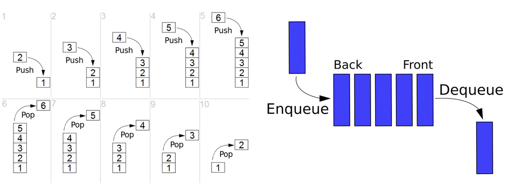

#### Q1. (stack) Implement the stack data structure using a linked list.

#### Q2. (stack) Using the stack in Q1 , Write and test a program that extracts postfix expressions from the user, evaluates the expression, and prints the results. You may require that the user enter numeric values along with the operators and that each component of the expression be separated with white space.

#### Q3. (stack) Using the stack in Q1 , write a program to check for balanced parentheses, brackets and braces. The program also ignores these symbols when they are part of a comment (lines beginning with //).

- For example, the following snippet is valid:  
  `int values (int arr[]) // (this is fun!`
- And this is not:  
  `int values (int arr[])] // (this is fun!`

#### Q4. (queue) Implement the queue data structure using a singly linked list.

#### Q5. (queue) Implement the Priority Queue ADT using an unsorted linked list.

#### Q6. (queue) A deque (pronounced “deck”) is similar to a queue, except that elements can be enqueued at either end and dequeued from either end. Define a Deque ADT and then provide an implementation for your definition.

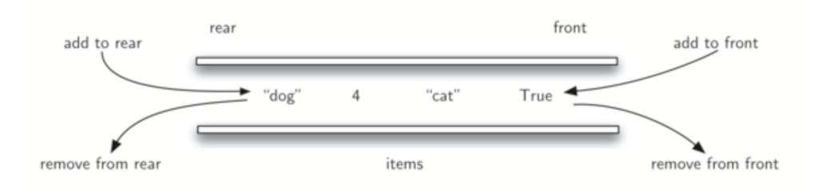